# How to Grow on Twitch

By: Matthew Simmons

## Introduction

Next month will mark 10 years since Twitch.tv was introduced to the Internet. Twitch.tv is a live streaming service that focuses on video games and esports competitions, although it also offers a variety of other content. Since then, many things have changed on Twitch - particularly in its popularity. Many people, back then and now, have begun to stream on Twitch - either as a side passion or as a full-time job. For these people, it is important to understand how to grow their community and outreach in order to make money - it's their livelihood! We will answer the long-standing question of how to grow on Twitch so that we may be able to become a large Twitch stream someday.

## Data Collection

It is important that we gather trustworthy and reliable data points for our project. Why would be check the statistics of the average breadbaker if we are trying to grow popular? For this reason, we will be analyzing a subset of Twitch streamers based on how large and successful they are - that is, we will gather data from the top Twitch streamers and use this to base our analysis on.

Initially, I looked through the data provided by the final project's specifications and found this kaggle source: https://www.kaggle.com/aayushmishra1512/twitchdata. This source has data on the Top 1000 Twitch streamers based on watch time. Unfortunately, I could not find much use in it, as most data gathered are uncontrollable factors (e.g., average viewership, total followers, whether they're partnered, etc.) and we are trying to figure out what we can do to maximize our viewers. I continued to search on Kaggle, and I found another similar set of data: https://www.kaggle.com/girlazo/top-8800-twitch-streamers. This data set is essentially the same as the above set, but it has two important differences that make it desirable. First, there are more controllable factors, which we will get into in the data analysis. Second, this data set has the top 8800 Twitch streamers rather than the top 1000. This is important because the lower rankings are more realistic - comparing with the other, lower numbers will help us see realistically what we can control, as it is possible the largest people got big through unconventional means such as luck.

### Libraries

I imported several libraries for this project. The purpose of this is to make our lives easier in terms of data management and visualization.

- Pandas: This is used to organize data into manipulable tables called dataframes.
- Numpy: This gives us access to several ways to manipulate the data. I mostly use to to plot regression lines.
- Matplotlib: This is used to take in data sets and turn them into visual plots.
- Seaborn: This works in conjunction with Matplotlib to create other kinds of plots. Also, its plots are more visually appealing.
- Statsmodels.api: This is the library we will use to perform our linear regression.
- Sklearn.tree: This will allow us to create a Decision Tree.

```python
import pandas as pd
import numpy as np
import matplotlib.pyplot as plt
import seaborn as sns
import statsmodels.api as sm
from sklearn import tree
from sklearn.model_selection import train_test_split
```

### Loading the Data

On Kaggle, we are able to download the datasets into a CSV file. From there, we can input that file and put it inside a dataframe. This allows us to manipulate our data.

```python
df = pd.read_csv('TwitchDataSet.csv')
df.columns = ['picture', 'ranking', 'name', 'watch_time', 'stream_time', 'max_viewers', 'average_viewers',
              'total_followers', 'delta_followers', 'delta_viewers', 'partnered', 'mature', 'language',
              'complete_name', 'cat_1', 'cat_2', 'cat_3']

# These two are not useful to us at all, pictures are links and complete_name is just another name.
df = df.drop(columns=['picture', 'complete_name'])

df.head()
```

|  | ranking | name | watch_time | stream_time | max_viewers | average_viewers | total_followers | delta_followers | delta_viewers | partnered | mature | language | cat_1 | cat_2 | cat_3 |
| --- | --- | --- | --- | --- | --- | --- | --- | --- | --- | --- | --- | --- | --- | --- | --- |
| 0 | 1 | xQcOW | 7333609065 | 215670 | 222720 | 32913 | 3691010 | 2051895 | 109735389 | True | False | English | Just Chatting | Among Us | Overwatch |
| 1 | 2 | Gaules | 6314532585 | 515595 | 387315 | 12254 | 1966465 | 1141123 | 112807468 | True | True | Portuguese | Counter-Strike: Global Offensive | Among Us | PLAYERUNKNOWN |
| 2 | 3 | summit1g | 6235007490 | 216000 | 310998 | 25931 | 5374710 | 1402547 | 91501875 | True | False | English | Escape From Tarkov | Sea of Thieves | Grand Theft Auto V |
| 3 | 4 | ESL_CSGO | 4764929775 | 517965 | 300575 | 9249 | 4195657 | 870484 | 126008641 | True | False | English | Counter-Strike: Global Offensive | NaN | NaN |
| 4 | 5 | NICKMERCS | 3853252845 | 131880 | 163241 | 29183 | 4415637 | 1337535 | 49164651 | True | False | English | Call Of Duty: Modern Warfare | Fortnite | Halo: The Master Chief Collection |

The data is split into several columns:

```python
df.describe(include='all')
```

|  | ranking | name | watch_time | stream_time | max_viewers | average_viewers | total_followers | delta_followers | delta_viewers | partnered | mature | language | cat_1 | cat_2 | cat_3 |
| --- | --- | --- | --- | --- | --- | --- | --- | --- | --- | --- | --- | --- | --- | --- | --- |
| count | 8800.000000 | 8800 | 8.800000e+03 | 8800.000000 | 8.800000e+03 | 8800.000000 | 8.800000e+03 | 8.800000e+03 | 8.800000e+03 | 8800 | 8800 | 8799 | 8795 | 8390 | 8009 |
| unique | NaN | 8800 | NaN | NaN | NaN | NaN | NaN | NaN | NaN | 2 | 2 | 30 | 403 | 684 | 844 |
| top | NaN | Sev7n | NaN | NaN | NaN | NaN | NaN | NaN | NaN | True | False | English | Just Chatting | Just Chatting | Just Chatting |
| freq | NaN | 1 | NaN | NaN | NaN | NaN | NaN | NaN | NaN | 7884 | 6219 | 4015 | 1365 | 1264 | 792 |
| mean | 4400.500000 | NaN | 7.800300e+07 | 87333.923864 | 1.004556e+04 | 1258.528409 | 1.451799e+05 | 5.995087e+04 | 2.547306e+06 | NaN | NaN | NaN | NaN | NaN | NaN |
| std | 2540.485518 | NaN | 2.447944e+08 | 68324.434807 | 2.746978e+04 | 4055.010692 | 3.947905e+05 | 1.613823e+05 | 9.747832e+06 | NaN | NaN | NaN | NaN | NaN | NaN |
| min | 1.000000 | NaN | 8.827995e+06 | 120.000000 | 7.300000e+01 | 16.000000 | 4.900000e+01 | -1.785700e+05 | 3.640000e+02 | NaN | NaN | NaN | NaN | NaN | NaN |
| 25% | 2200.750000 | NaN | 1.298649e+07 | 43526.250000 | 1.556000e+03 | 175.000000 | 2.252600e+04 | 7.519750e+03 | 3.614605e+05 | NaN | NaN | NaN | NaN | NaN | NaN |
| 50% | 4400.500000 | NaN | 2.225172e+07 | 77122.500000 | 3.490000e+03 | 358.000000 | 5.258050e+04 | 1.914800e+04 | 7.697435e+05 | NaN | NaN | NaN | NaN | NaN | NaN |
| 75% | 6600.250000 | NaN | 5.236439e+07 | 114056.250000 | 8.461500e+03 | 949.000000 | 1.324780e+05 | 5.237975e+04 | 2.131818e+06 | NaN | NaN | NaN | NaN | NaN | NaN |
| max | 8800.000000 | NaN | 7.333609e+09 | 521115.000000 | 1.016962e+06 | 193645.000000 | 1.604258e+07 | 4.681567e+06 | 6.848357e+08 | NaN | NaN | NaN | NaN | NaN | NaN |

## Analysis & Visualization

Now, it is time to analyze the data. For the most part, we will be analyzing only the controllable factors (it doesn't help us to find a correlation with something we can't apply or use!). These are maturity, stream time, language (somewhat), and the streaming categories. One can argue that a change in followers can be controlled by using bot accounts.

First, let us compare with maturity: does being a mature-rated streamer yield more or less viewers? To compare, we will plot the distributions of both mature streamers and kid-friendly streamers.

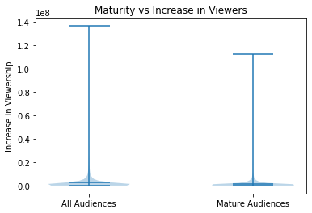

```python
viewers_on_maturity = [[], []]

# For clarity in the plots, we remove the extremely large outlier - the plots are useless if it is included!
# It is still included in the overall analysis.
df2 = df[df['delta_viewers'] != df['delta_viewers'].max()]

for (i, series) in df2.iterrows():
    viewers_on_maturity[1 if series['mature'] else 0].append(series['delta_viewers'])

plt.violinplot(viewers_on_maturity, [1, 2], showmeans=True);
plt.xticks([1, 2], ['All Audiences', 'Mature Audiences'])
plt.ylabel('Increase in Viewership')
plt.title('Maturity vs Increase in Viewers');
```

The two violin plots have roughly the same shape. However, the mean increase in viewers appears to be larger in the kid-friendly plot. It appears that mature streamers gain less viewers than the kid-friendly ones. Intuitively, this makes sense: the kid-friendly streamers simply have a larger pool of people to have view their streams.

Next, let us look at stream time. Is there a significant increase in the viewership of the streamer when they stream more?

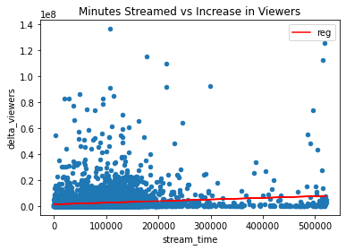

```python
ax = df2.plot.scatter(x='stream_time', y='delta_viewers')

# Creating regression line
plot = np.poly1d(np.polyfit(df2['stream_time'], df2['delta_viewers'], 1))
df2.insert(3, 'reg', plot(df2['stream_time']))
df2.plot(x='stream_time', y='reg', ax = ax, c = 'r', title='Minutes Streamed vs Increase in Viewers');
```

From this scatter plot, we can see that there is a positive trend in the data - however, it is not enough to conclude anything here.

Next, we will look at the increase in followers: do more followers lead to more viewers?

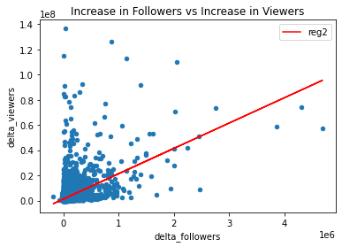

```python
ax = df2.plot.scatter(x='delta_followers', y='delta_viewers')

# Creates the regression line
plot = np.poly1d(np.polyfit(df2['delta_followers'], df2['delta_viewers'], 1))
df2.insert(3, 'reg2', plot(df2['delta_followers']))
df2.plot(x='delta_followers', y='reg2', ax = ax, c = 'r', title='Increase in Followers vs Increase in Viewers');
```

Once again, there is a positive, linear relationship between an increase in followers and an increase in viewers. We will observe later how strong it is.

Now, we want to map all of our numerical data to see what is likely to impact the change in viewership. To do this, we can use a heatmap on the pairwise correlations of the data columns. Here, red means a high positive correlation, blue a high negative, and white no correlation. More intense colors mean a stronger correlation. For more information on correlation matrices, see https://www.displayr.com/what-is-a-correlation-matrix/.

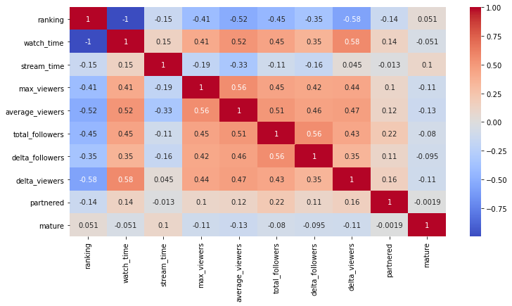

```python
plt.figure(figsize=(12,6))
sns.heatmap(df.corr(method='kendall'), annot=True, cmap = 'coolwarm');
```

Unfortunately, this tells us that there is little correlation between the change in viewers and the controllable factors we have tried so far. The one with the highest correlation is delta_followers, so we will continue to use this in the Machine Learning section.

Now, let us take a look at the non-numerical data. First, we will take a look at language: how does the stream's language impact the increase in viewership?

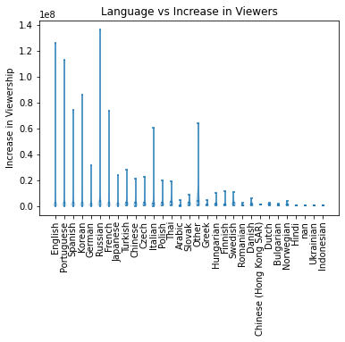

```python
viewers_on_language = [[] for i in range(len(df2.language.unique()))]

languages = df2.language.unique().tolist()

# Looks through each row and adds the data to the corresponding language
for (i, series) in df2.iterrows():
    viewers_on_language[languages.index(series['language'])].append(series['delta_viewers'])

plt.violinplot(viewers_on_language, [i + 1 for i in range(len(languages))], showmeans=True)

plt.xticks([i + 1 for i in range(len(languages))], languages, rotation='vertical')
plt.ylabel('Increase in Viewership')
plt.title('Language vs Increase in Viewers');
```

Unfortunately, due to the vastly different ranges in the data, this is hard to interpret. Instead, we will compare based on each language's average increase in viewership.

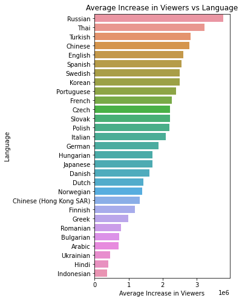

```python
df_temp = df.copy()

# Remove 'Other' language - it's not useful to us.
df_temp = df_temp[df_temp['language'] != 'Other']

df_lang = df_temp.groupby('language')['delta_viewers'].mean()

# Convert groupby object to a dictionary
languages = {}
for lang in df_lang.index.get_level_values(0):
    languages[lang] = df_lang[lang]

# Convert dictionary to tuple list
tup = list(languages.items())
tup.sort(key=lambda x: x[1], reverse=True)

plt.figure(figsize=(4,8))
sns.barplot(x=[x[1] for x in tup], y=[x[0] for x in tup])
plt.xlabel('Average Increase in Viewers')
plt.ylabel('Language')
plt.title('Average Increase in Viewers vs Language');
```

Now let's take a look at another divisive part of Twitch: the streaming category. Let's see which categories lead to a larger increase in viewers. Due to the large number of categories on Twitch, we will only display the top 100 categories ranked by the increase in viewership.

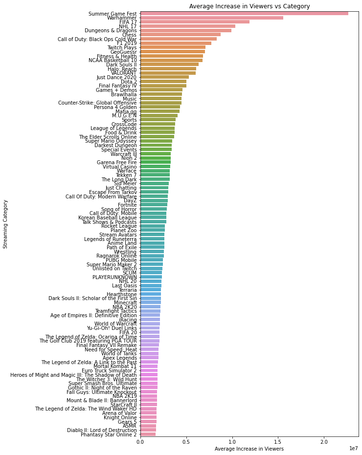

```python
df_temp = df.copy()

df_cat = df_temp.groupby('cat_1')['delta_viewers'].mean()

# Convert the groupby object to a dictionary
categories = {}
for cat in df_cat.index.get_level_values(0):
    categories[cat] = df_cat[cat]

# Convert the dictionary to a tuple list
tup = list(categories.items())
tup.sort(key=lambda x: x[1], reverse=True)

# Taking the top 100 for readability
tup = tup[:100]

plt.figure(figsize=(8,16))

# x = viewers, y = category
sns.barplot(x=[x[1] for x in tup], y=[x[0] for x in tup])

plt.xlabel('Average Increase in Viewers')
plt.ylabel('Streaming Category')
plt.title('Average Increase in Viewers vs Category');
```

Other than these, the largest of the standard gaming categories are at the top: Sports games such as FIFA, FPS games such as Call of Duty, and racing games such as Formula One are in the top 10.

Now, let's take a look to see if a second category is a noticeable difference in terms of viewers from the first.

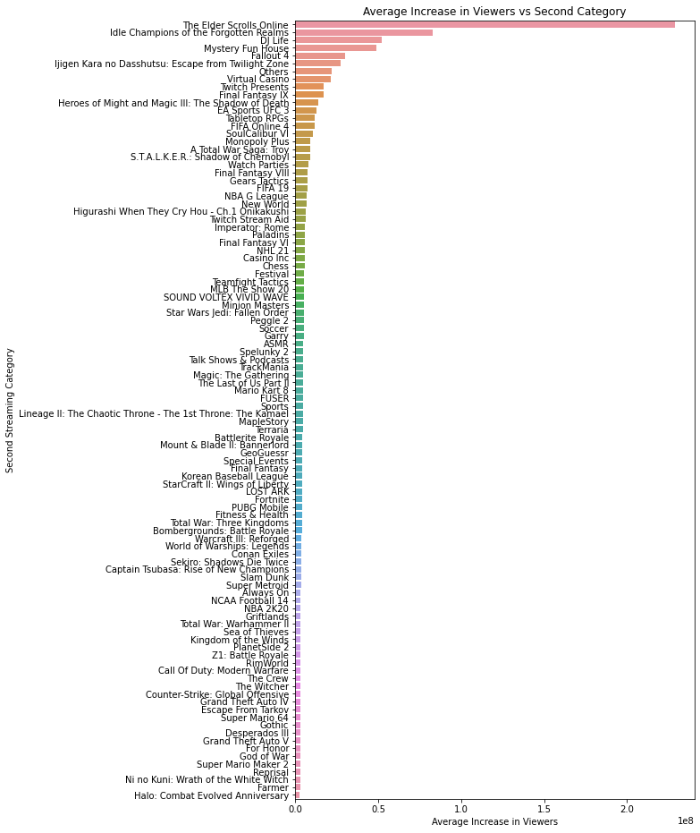

```python
df_temp = df.copy()

df_temp = df_temp[(pd.notnull(df_temp['cat_2']))]

df_cat = df_temp.groupby('cat_2')['delta_viewers'].mean()

categories = {}
for cat in df_cat.index.get_level_values(0):
    categories[cat] = df_cat[cat]

tup = list(categories.items())
tup.sort(key=lambda x: x[1], reverse=True)

tup = tup[:100]

plt.figure(figsize=(8,16))
sns.barplot(x=[x[1] for x in tup], y=[x[0] for x in tup])
plt.xlabel('Average Increase in Viewers')
plt.ylabel('Second Streaming Category')
plt.title('Average Increase in Viewers vs Second Category');
```

Initially, I was not going to consider the third category, but due to the major difference between the first two, we should see how different it is, as well.

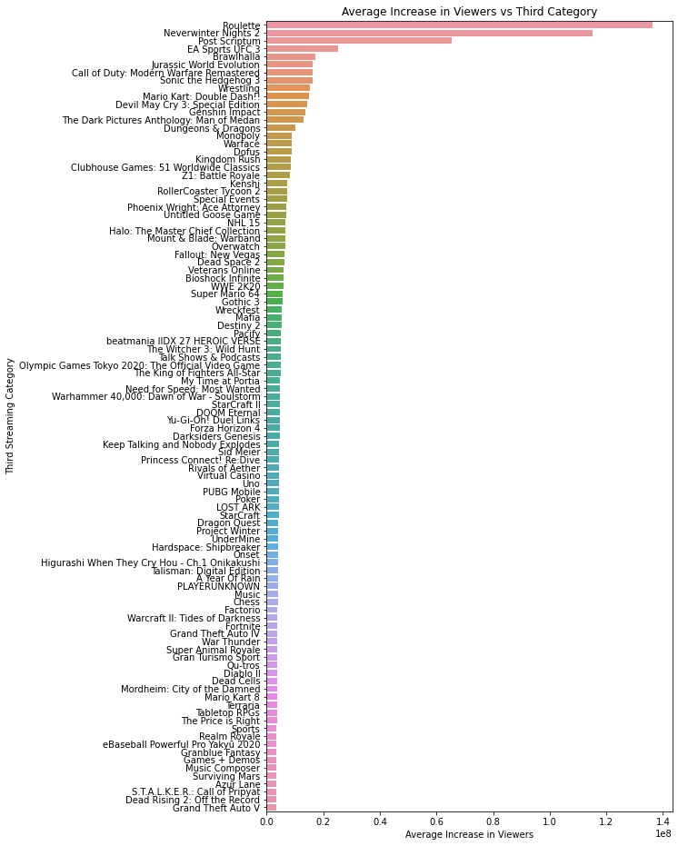

```python
df_temp = df.copy()

df_temp = df_temp[(pd.notnull(df_temp['cat_3']))]

df_cat = df_temp.groupby('cat_3')['delta_viewers'].mean()

categories = {}
for cat in df_cat.index.get_level_values(0):
    categories[cat] = df_cat[cat]

tup = list(categories.items())
tup.sort(key=lambda x: x[1], reverse=True)

tup = tup[:100]

plt.figure(figsize=(8,16))
sns.barplot(x=[x[1] for x in tup], y=[x[0] for x in tup])
plt.xlabel('Average Increase in Viewers')
plt.ylabel('Third Streaming Category')
plt.title('Average Increase in Viewers vs Third Category');
```

In the third category, it appears to be a mix of the other two topped with Roulette. Many top streamers have been gambling real money on their streams, which has attracted viewers. Apart from this, the top list is filled with RPGs and other traditional video games.

## Machine Learning

We have seen several potential driving factors of increasing Twitch viewership, namely an increase in followers, language, and Twitch category. Now, we will model these and see how well these act as predictors. Unfortunately due to the vast size of the number of categories, we will not be able to consider the streaming categories as an option (sklearn is currently working on an implementation regarding this: https://github.com/scikit-learn/scikit-learn/pull/12866). Because of this, we will stick to the other two potentially significant columns: increase in followers and language. I have decided to try both a Linear Regression Model and a Decision Tree Model.

### Regression

We implement our linear regression using an OLS, which is the traditional least-squares regression (https://www.statisticshowto.com/probability-and-statistics/statistics-definitions/least-squares-regression-line/). Notice that when converting our categorical languages to other variables, we drop the first value in order to avoid the dummy variable trap and have too many variables.

```python
temp_df = df2.copy()

temp_df = temp_df[temp_df['language'] != 'Other']

temp_df = temp_df[pd.notnull(temp_df['language'])]
temp_df = temp_df[pd.notnull(temp_df['delta_followers'])]

language_features = pd.get_dummies(temp_df.language, drop_first=True, prefix='lang')

standard_features = temp_df[['delta_followers', 'delta_viewers']]

concat_features = pd.concat([standard_features, language_features], axis=1)

languages = temp_df.language.unique().tolist()

# Arabic is our dummy value
for l in filter(lambda x: (x != 'Arabic'), languages):
    concat_features['followers*'+l] = concat_features['lang_'+l] * concat_features['delta_followers']

X = sm.add_constant(concat_features.drop('delta_viewers', axis=1))
y = concat_features['delta_viewers']

results = sm.OLS(y, X).fit()

results.summary()
```

OLS Regression Results

| Dep. Variable: | delta_viewers | R-squared: | 0.303 |
| --- | --- | --- | --- |
| Model: | OLS | Adj. R-squared: | 0.298 |
| Method: | Least Squares | F-statistic: | 67.64 |
| Date: | Mon, 17 May 2021 | Prob (F-statistic): | 0.00 |
| Time: | 19:06:44 | Log-Likelihood: | -1.4856e+05 |
| No. Observations: | 8780 | AIC: | 2.972e+05 |
| Df Residuals: | 8723 | BIC: | 2.976e+05 |
| Df Model: | 56 |  |  |
| Covariance Type: | nonrobust |  |  |

|  | coef | std err | t | P>\|t\| | [0.025 | 0.975] |
| --- | --- | --- | --- | --- | --- | --- |
| const | 6.127e+04 | 9.41e+05 | 0.065 | 0.948 | -1.78e+06 | 1.91e+06 |
| delta_followers | 5.4423 | 5.598 | 0.972 | 0.331 | -5.530 | 16.415 |
| lang_Bulgarian | 3.949e+05 | 3.59e+06 | 0.110 | 0.912 | -6.64e+06 | 7.43e+06 |
| lang_Chinese | 5.978e+05 | 1.06e+06 | 0.563 | 0.573 | -1.48e+06 | 2.68e+06 |
| lang_Chinese (Hong Kong SAR) | 1.115e+06 | 6.21e+06 | 0.180 | 0.857 | -1.11e+07 | 1.33e+07 |
| lang_Czech | 8.724e+05 | 1.34e+06 | 0.650 | 0.516 | -1.76e+06 | 3.51e+06 |
| lang_Danish | 5.118e+05 | 2.44e+06 | 0.210 | 0.834 | -4.27e+06 | 5.3e+06 |
| lang_Dutch | 9.356e+05 | 2.74e+06 | 0.341 | 0.733 | -4.44e+06 | 6.31e+06 |
| lang_English | 9.922e+05 | 9.46e+05 | 1.049 | 0.294 | -8.61e+05 | 2.85e+06 |
| lang_Finnish | 3.072e+05 | 1.89e+06 | 0.163 | 0.871 | -3.4e+06 | 4.01e+06 |
| lang_French | 4.477e+05 | 9.86e+05 | 0.454 | 0.650 | -1.49e+06 | 2.38e+06 |
| lang_German | 8.156e+05 | 9.76e+05 | 0.836 | 0.403 | -1.1e+06 | 2.73e+06 |
| lang_Greek | -1.888e+05 | 2.16e+06 | -0.088 | 0.930 | -4.42e+06 | 4.04e+06 |
| lang_Hindi | 5.924e+05 | 8.63e+06 | 0.069 | 0.945 | -1.63e+07 | 1.75e+07 |
| lang_Hungarian | 3.566e+05 | 1.44e+06 | 0.248 | 0.804 | -2.47e+06 | 3.18e+06 |
| lang_Indonesian | 1.281e+06 | 9.14e+07 | 0.014 | 0.989 | -1.78e+08 | 1.8e+08 |
| lang_Italian | 1.083e+06 | 1.07e+06 | 1.011 | 0.312 | -1.02e+06 | 3.18e+06 |
| lang_Japanese | 1.431e+05 | 1.1e+06 | 0.131 | 0.896 | -2e+06 | 2.29e+06 |
| lang_Korean | 7.893e+05 | 9.79e+05 | 0.806 | 0.420 | -1.13e+06 | 2.71e+06 |
| lang_Norwegian | 8.621e+04 | 4.61e+06 | 0.019 | 0.985 | -8.94e+06 | 9.11e+06 |
| lang_Polish | 6.491e+05 | 1.11e+06 | 0.587 | 0.557 | -1.52e+06 | 2.82e+06 |
| lang_Portuguese | 2.331e+05 | 9.74e+05 | 0.239 | 0.811 | -1.68e+06 | 2.14e+06 |
| lang_Romanian | -1.453e+05 | 3.38e+06 | -0.043 | 0.966 | -6.77e+06 | 6.48e+06 |
| lang_Russian | 1.934e+06 | 9.71e+05 | 1.992 | 0.046 | 3.07e+04 | 3.84e+06 |
| lang_Slovak | 2.491e+06 | 3.22e+06 | 0.774 | 0.439 | -3.81e+06 | 8.8e+06 |
| lang_Spanish | 6.234e+05 | 9.65e+05 | 0.646 | 0.518 | -1.27e+06 | 2.52e+06 |
| lang_Swedish | 1.551e+06 | 1.96e+06 | 0.790 | 0.429 | -2.3e+06 | 5.4e+06 |
| lang_Thai | -2.056e+05 | 1.56e+06 | -0.132 | 0.895 | -3.27e+06 | 2.86e+06 |
| lang_Turkish | 6.211e+05 | 1.04e+06 | 0.595 | 0.552 | -1.43e+06 | 2.67e+06 |
| lang_Ukrainian | 21.5114 | 301.477 | 0.071 | 0.943 | -569.454 | 612.477 |
| followers*English | 19.0253 | 5.625 | 3.382 | 0.001 | 7.999 | 30.051 |
| followers*Portuguese | 21.0029 | 5.787 | 3.629 | 0.000 | 9.659 | 32.347 |
| followers*Spanish | 7.9266 | 5.626 | 1.409 | 0.159 | -3.102 | 18.955 |
| followers*Korean | 43.3933 | 6.901 | 6.288 | 0.000 | 29.866 | 56.920 |
| followers*German | 20.0659 | 6.201 | 3.236 | 0.001 | 7.910 | 32.221 |
| followers*Russian | 36.7576 | 6.067 | 6.059 | 0.000 | 24.866 | 48.649 |
| followers*French | 24.0566 | 6.202 | 3.879 | 0.000 | 11.900 | 36.213 |
| followers*Japanese | 83.4310 | 18.453 | 4.521 | 0.000 | 47.259 | 119.603 |
| followers*Turkish | 24.9001 | 6.601 | 3.772 | 0.000 | 11.961 | 37.839 |
| followers*Chinese | 156.5483 | 25.554 | 6.126 | 0.000 | 106.456 | 206.640 |
| followers*Czech | 22.3480 | 14.627 | 1.528 | 0.127 | -6.325 | 51.021 |
| followers*Italian | 8.8684 | 7.394 | 1.199 | 0.230 | -5.626 | 23.362 |
| followers*Polish | 33.0104 | 10.525 | 3.136 | 0.002 | 12.379 | 53.642 |
| followers*Thai | 107.5617 | 33.954 | 3.168 | 0.002 | 41.004 | 174.120 |
| followers*Slovak | -10.9400 | 40.649 | -0.269 | 0.788 | -90.622 | 68.742 |
| followers*Greek | 77.0652 | 112.305 | 0.686 | 0.493 | -143.079 | 297.209 |
| followers*Hungarian | 50.3428 | 35.550 | 1.416 | 0.157 | -19.343 | 120.029 |
| followers*Finnish | 54.1922 | 95.750 | 0.566 | 0.571 | -133.501 | 241.886 |
| followers*Swedish | 39.9365 | 64.366 | 0.620 | 0.535 | -86.236 | 166.109 |
| followers*Romanian | 49.6232 | 166.849 | 0.297 | 0.766 | -277.440 | 376.687 |
| followers*Danish | 42.1165 | 88.653 | 0.475 | 0.635 | -131.665 | 215.898 |
| followers*Chinese (Hong Kong SAR) | 41.1110 | 1459.682 | 0.028 | 0.978 | -2820.210 | 2902.432 |
| followers*Dutch | 14.0967 | 95.721 | 0.147 | 0.883 | -173.539 | 201.732 |
| followers*Bulgarian | 9.4589 | 174.761 | 0.054 | 0.957 | -333.114 | 352.032 |
| followers*Norwegian | 129.6320 | 426.379 | 0.304 | 0.761 | -706.171 | 965.435 |
| followers*Hindi | -11.7939 | 195.257 | -0.060 | 0.952 | -394.543 | 370.956 |
| followers*Ukrainian | 2904.0441 | 4.07e+04 | 0.071 | 0.943 | -7.69e+04 | 8.27e+04 |
| followers*Indonesian | -123.6161 | 1.1e+04 | -0.011 | 0.991 | -2.17e+04 | 2.14e+04 |

| Omnibus: | 13514.234 | Durbin-Watson: | 1.474 |
| --- | --- | --- | --- |
| Prob(Omnibus): | 0.000 | Jarque-Bera (JB): | 8707465.264 |
| Skew: | 9.618 | Prob(JB): | 0.00 |
| Kurtosis: | 156.074 | Cond. No. | 1.08e+16 |

Notes:  
[1] Standard Errors assume that the covariance matrix of the errors is correctly specified.  
[2] The smallest eigenvalue is 3.03e-18. This might indicate that there are  
strong multicollinearity problems or that the design matrix is singular.

Here, we can see that our linear regression has R^2 of 0.303. 0.3 is not very good, as this says our model does not perform well when predicting the data. However, this is also expected, since viewership is predicting human behavior and it is very challenging to predict that.

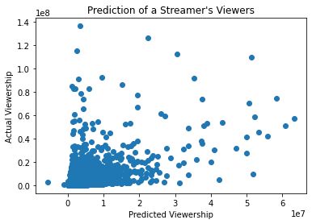

```python
y_hat = results.predict(X)

plt.scatter(x=y_hat, y=y)
plt.xlabel('Predicted Viewership')
plt.ylabel('Actual Viewership')
plt.title('Prediction of a Streamer\'s Viewers');
```

This scatter plot represents the predicted data and the true data. In a perfect model, we would have a perfect line of y=x, but that is clearly not the case here.

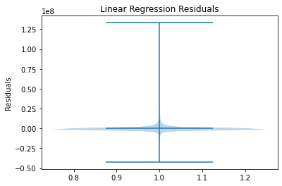

```python
plt.violinplot(y - y_hat, showmeans=True)
plt.ylabel('Residuals')
plt.title('Linear Regression Residuals');
```

This plot shows the residual of our model, or how far off we typically are. Contrary to the previous data, our residuals are centered at 0 and is unimodal. It is very possible that our model is actually quite good on the smaller-scale, only failing a large amount for the extremely large, top 100 streamers.

### Decision Tree

Decision Trees are created out of a sequence of binary questions, i.e. questions with 2 answers. The ability to learn from these gets the answer quite quickly, making it a widely used model. For more, see https://en.wikipedia.org/wiki/Decision_tree.

Here, we create such a tree. We then run through sample tests and score the accuracy of the tree.

```python
# Creates 2 sets of data - training data and testing data - by splitting the data 30/70.
X_train, X_test, y_train, y_test = train_test_split(X, y, test_size = 0.3, random_state = 2)

tree1 = tree.DecisionTreeRegressor(max_depth=15)

# Fits the data to the tree
tree1.fit(X_train, y_train)

acc = tree1.score(X_train, y_train)
score = tree1.score(X_test, y_test)

print("Accuracy in Training: " + str(acc))
print("Accuracy in Tests: " + str(score))
```

```
Accuracy in Training: 0.8272400144532557
Accuracy in Tests: -0.10492644166928677
```

Here, we see some interesting scores. Our model is able to accurately predict 83% of the data it was taught - better than the average student. However, it is not very good at testing other data, as it has a -10% accuracy in this.

Because both models are not very accurate, we can say that there is little correlation between language and increase in followers with the increase in a streamer's viewership.

## Conclusion

In this tutorial, we looked through various ways of connecting top Twitch streamer's data to their ability to gain viewers. We explored these using a heat map, scatter plots, violin plots, and bar plots. We then took an idea and applied the methods of machine learning to it - we checked whether language and followers had a correlation with the number of viewers a streamer has. This was done with two different methods, a linear regression model and a decision tree model. Both models told us that there was little correlation between them. We have left category unexplored due to a lack of implementation in our chosen packages.

Thank you for your time and for reading this in full!